# Student Success Project

Ellie Hoog, Brady Stultz

22 October, 2023

## Audience and Purpose

Our findings will be presented to Kirk Bogard, Associate Vice President for Development and External Relations at FSB. Kirk and his team will use the data and our findings to: 1. Inform FSB rankings 2. Make their case for admission (parents = facts and figures, students = fit and feel) 3. Attract other companies to recruit from FSB 4. Help influence the types of jobs and salary levels they see offered to FSB students 5. FSB Brand Management (sound bites such as: “Farmer students are job ready on Day 1”)

Our audience also includes Dr. Allison Jones-Farmer, a shared work practitioner.

## Student Success Business Value Proposition

For this project, we will examine the correlation between internships and full-time placement. More specifically, we will answer the following questions:

1. If a student has at least one internship, how much more likely are they to have a full-time job than if they did not have an internship?
2. What if a student has two internships?
3. Does having an internship mean your salary level will be higher in your full-time job?

From our team’s personal experience, we have found that there is immense pressure on students to secure at least one internship during their time at Miami. We are hoping our insights will shed more light on the subject using a data-centric approach.

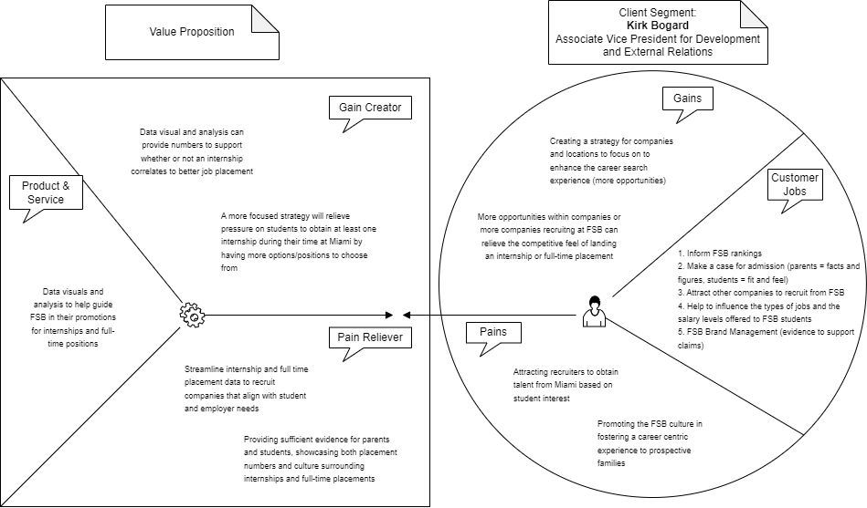

## Exploring the Data

```r
data = readRDS(file = "FSB_BI_Survey_2019_2021.rds")

head(data)
```

|  | nmajor | major1 | major2 | BBRJ | Business Direct Admit | Combined Bacc and Masters | Dean's List | First Generation College Stdnt | FSB Scholars | Honors Program | President's List | Study Abroad Courtesy Account | Transfer Work (Pre-Banner) | Cum Laude | Magna Cum Laude | Summa Cum Laude | University Honors | UniversityHonors w/Distinction | minor1 | minor2 | IPEDS.Race.Ethnicity | Gender | GPA.Range | Term.Code | year.x | latin_honors | survey_city | survey_company | survey_deptfunc | … |
| --- | --- | --- | --- | --- | --- | --- | --- | --- | --- | --- | --- | --- | --- | --- | --- | --- | --- | --- | --- | --- | --- | --- | --- | --- | --- | --- | --- | --- | --- | --- |
| 1 | 1 | Marketing | none | 0 | 1 | 0 | 0 | 0 | 0 | 0 | 0 | 0 | 0 | 0 | 0 | 0 | 0 | 0 | No Minor | No Minor | Hispanic/Latino | Male | 2.00 - 2.49 | 202015 | 2020 | 0 | NA | NA | NA | … |
| 2 | 1 | Finance | none | 0 | 1 | 0 | 0 | 0 | 0 | 0 | 0 | 0 | 0 | 0 | 0 | 0 | 0 | 0 | Business Legal Studies | No Minor | White | Male | 3.00 - 3.49 | 201920 | 2019 | 0 | Toledo | BAM Nutual | Finance | … |
| 3 | 1 | Marketing | none | 0 | 1 | 0 | 1 | 0 | 0 | 0 | 0 | 0 | 0 | 1 | 0 | 0 | 0 | 0 | Humanities | Humanities | Asian | Female | 3.50 - 4.00 | 202120 | 2021 | 0 | Columbus | CoHatch | General Management | … |
| 4 | 1 | Finance | none | 0 | 1 | 0 | 0 | 1 | 0 | 0 | 0 | 0 | 0 | 0 | 0 | 0 | 0 | 0 | Accountancy | Accountancy | White | Male | 3.00 - 3.49 | 202020 | 2020 | 0 | NA | PwC | NA | … |
| 5 | 1 | Marketing | none | 0 | 1 | 0 | 1 | 0 | 0 | 0 | 0 | 0 | 0 | 0 | 0 | 0 | 0 | 0 | Supply Chain Management | Supply Chain Management | White | Male | 3.00 - 3.49 | 201920 | 2019 | 0 | Columbus | Abercrombie & Fitch | General Management | … |
| 6 | 1 | Marketing | none | 0 | 1 | 0 | 0 | 0 | 0 | 0 | 0 | 0 | 1 | 0 | 0 | 0 | 0 | 0 | Humanities | Humanities | White | Female | 3.00 - 3.49 | 202020 | 2020 | 0 | Cleveland | McDonald's | Consulting Marketing / Sales Operations / Procurement | … |

The data source includes three years of data representing FSB graduates, including graduates in 2019, 2020, and 2021. The dataset provided had 42 variables. The source is either derived by me during data cleaning/merging, from the Oracle Business Intelligence Enterprise Edition (OBIEE) maintained by Miami administration, or from the self reported senior survey. The data is a mixture of numeric and categorical variables.

nmajor: numeric,derived, the number of majors

major1: text, OBIEE, first major

major 2: text, OBIEE, second major

BBRJ: binary, OBIEE, an attribute of a student, but we do not know what this stands for

Business Direct Admit: binary, OBIEE, a direct admit to FSB as a first year

Combined Cacc and Masters: binary, OBIEE, combined degree student

Dean’s List: binary, OBIEE, achieve dean’s list status at least once

First Generation College Stdnt: binary, OBIEE, first generation student status

FSB Scholars: binary, OBIEE, FSB scholars program

Honors Program: binary, OBIEE, member of University honors program

President’s list: binary, OBIEE, achieved president’s list at least once

Study Abroud Courtesy Account: binary, OBIEE, do not know meaning

Transfer Work: binary, OBIEE, do not know exact meaning

Cum Laude: binary, OBIEE, graduated Cum Laude

Magna Cum Laude: binary, OBIEE, graduated Magna Cum Laude

Summa Cum Laude: binary, OBIEE, graduated Summa Cum Laude

University Honors: binary, OBIEE, graduated with University Honors

University Honors w/Distinction: binary, OBIEE, graduated with University Honors with Distinction

minor1: text, OBIEE, first listed minor

minor2: text, OBIEE, second listed minor

IPEDS.Race.Ethnicity: text, OBIEE, race/ethnicity

Gender: text, OBIEE, sex

GPA.Range: text, OBIEE, GPA within a .5 range

Term.Code: numberic, OBIEE, First four digits are the physcal year (beginning in July, e.g. July 2020 is FY 2021). Last two digits is the term (10=fall, 15=winter, 20=spring, 30=summer).

Year.x: text, derived, first four digits of Term.Code stored as a character variable

latin_honors: text, survey, latin honors designation

survey_city: text, survey, student reported city in which their job is located

survey_company: text, survey, student reported company in which they accepted a job

survey_deptfunc: text, survey, student reported job function

survey_gradprogram: text, survey, student reported graduate program they will be attending

survey_gradschool: text, survey, stuent reported graduate school they will be attending

survey_internfour: text, survey, student reported fourth internship they held during college

survey_internthree: text, survey, student reported third internship they held during college

survey_interntwo: text, survey, student reported second internship they held during college

survey_internone: text, survey, student reported first internship they held during college

Survey_internships: text, survey, Student reported number of internships they held during college

survey_offers: text, survey, student reported number of offers for full time employment received

survey_plans: text, survey, student reported plans after graduation

survey_pref_field: text, survey, student reported whether working in preferred field

survey_pref_loc: text, survey, student reported whether working in preferred location

survey_salary: numeric, survey, student reported salary

survey_state: text, survey, student reported state in which job is located

## Data Pre-Processing

Initial drop of variables we feel are unnecessary for our given prompt regarding internships and full-time placement.

```r
# Dropping unnecessary variables

data$BBRJ = data$bbrj
data$`Business Direct Admit` = data$BusDirectAdmit
data$`Combined Bacc and Masters` = data$CombBandM
data$`Dean's List`= data$DL
data$`First Generation College Stdnt` = data$FGCS
data$`FSB Scholars` = data$FSBS
data$`Honors Program` = data$HP
data$`President's List` = data$PresList
data$`Study Abroad Courtesy Account` = data$SACA
data$`Transfer Work (Pre-Banner)`= data$TW
data$`Cum Laude` = data$CL
data$`Magna Cum Laude` = data$MCL
data$`Summa Cum Laude` = data$SCL
data$`University Honors` = data$UH
data$`UniversityHonors w/Distinction` = data$UHWD
data$IPEDS.Race.Ethnicity = data$Race
data$Gender = data$Gendergender
data$Term.Code = data$CodeTerm
data$latin_honors = data$honorlatin
data$survey_gradprogram = data$gradpsur
data$survey_gradschool = data$gradssur
```

We’re also dropping the following variables: survey_internone, survey_interntwo, survey_internthree, survey_internfour. Most of these values are “N/A”. For our analysis, we want to focus on the number of internships, not the company offering the internship.

```r
data$survey_internone = data$intern1
data$survey_interntwo = data$intern2
data$survey_internthree = data$intern3
data$survey_internfour = data$intern4
```

```r
summary(data)
```

```
##      nmajor                                 major1
##  Min.   :1.000   Finance                       :1037
##  1st Qu.:1.000   Marketing                     : 909
##  Median :1.000   Accountancy                   : 531
##  Mean   :1.067   Supply Chain & Operations Mgmt: 244
##  3rd Qu.:1.000   Business Economics            : 143
##  Max.   :2.000   Information Systems           : 132
##                  (Other)                       : 239
##                             major2                           minor1
##  none                          :3018   No Minor                 :1775
##  Finance                       :  89   Business Analytics       : 183
##  Marketing                     :  48   Humanities               : 180
##  Supply Chain & Operations Mgmt:  37   Language                 : 133
##  Business Analytics            :  18   Arts Related             : 130
##  Information Systems           :  17   Interactive Media Studies: 122
##  (Other)                       :   8   (Other)                  : 712
##                        minor2      GPA.Range            year.x
##  No Minor                 :2436   Length:3235        Length:3235
##  Humanities               :  98   Class :character   Class :character
##  Language                 :  96   Mode  :character   Mode  :character
##  Business Analytics       :  91
##  Arts Related             :  73
##  Interactive Media Studies:  69
##  (Other)                  : 372
##  survey_city        survey_company     survey_deptfunc    survey_internships
##  Length:3235        Length:3235        Length:3235        Length:3235
##  Class :character   Class :character   Class :character   Class :character
##  Mode  :character   Mode  :character   Mode  :character   Mode  :character
##
##
##
##
##  survey_offers      survey_plans       survey_pref_field  survey_pref_loc
##  Length:3235        Length:3235        Length:3235        Length:3235
##  Class :character   Class :character   Class :character   Class :character
##  Mode  :character   Mode  :character   Mode  :character   Mode  :character
##
##
##
##
##  survey_salary    survey_state
##  Min.   : 10000   Length:3235
##  1st Qu.: 52000   Class :character
##  Median : 58000   Mode  :character
##  Mean   : 58128
##  3rd Qu.: 65000
##  Max.   :175000
##  NA's   :1503
```

We installed the “zoo” package to use the na.fill() function.

```r
# install.packages("zoo")
pacman::p_load(zoo)
```

Many fields had blank values. In order to work with the data efficiently, we imputed the value “NA” into these fields using na.fill(). For the dashboard, we found it was easier to visualize the data if we did not impute missing values with NA.

```r
# Impute missing values with "NA"

# missing_values = is.na(data)
# num_mv = sum(missing_values)
# print(num_mv)

# data$nmajor = na.fill(data$nmajor, fill = "NA")
# data$major1 = na.fill(data$major1, fill = "NA")
# data$major2 = na.fill(data$major2, fill = "NA")
# data$minor1 = na.fill(data$minor1, fill = "NA")
# data$minor2 = na.fill(data$minor2, fill = "NA")
# data$GPA.Range = na.fill(data$GPA.Range, fill = "NA")
# data$year.x = na.fill(data$year.x, fill = "NA")
# data$survey_city = na.fill(data$survey_city, fill = "NA")
# data$survey_company = na.fill(data$survey_company, fill = "NA")
# data$survey_deptfunc = na.fill(data$survey_deptfunc, fill = "NA")
# data$survey_internships = na.fill(data$survey_internships, fill = "NA")
# data$survey_offers = na.fill(data$survey_offers, fill = "NA")
# data$survey_plans = na.fill(data$survey_plans, fill = "NA")
# data$survey_pref_field = na.fill(data$survey_pref_field, fill = "NA")
# data$survey_pref_loc = na.fill(data$survey_pref_loc, fill = "NA")
# data$survey_salary = na.fill(data$survey_salary, fill = "NA")
# data$survey_state = na.fill(data$survey_state, fill = "NA")
```

The variable salary is not imputing with “NA”. Rather than assuming a $0 or average salary, we would rather treat these values as null. To fix this, we are going to change the data type from “number” to “character”. For the dashboard, we found it was easier to visualize the data if we did not impute missing values with NA.

```r
# data$survey_salary = as.character(data$survey_salary)
# data$survey_salary = na.fill(data$survey_salary, fill = "NA")
```

## Final Clean Data

```r
head(data)
```

|  | nmajor | major1 | major2 | minor1 | minor2 | GPA.Range | year.x | survey_city | survey_company | survey_deptfunc | survey_internships | survey_offers | survey_plans | survey_pref_field | survey_pref_loc | survey_salary | survey_state |
| --- | --- | --- | --- | --- | --- | --- | --- | --- | --- | --- | --- | --- | --- | --- | --- | --- | --- |
| 1 | 1 | Marketing | none | No Minor | No Minor | 2.00 - 2.49 | 2020 | NA | NA | NA | NA | NA | seeking continuing education | NA | NA | NA | NA |
| 2 | 1 | Finance | none | Business Legal Studies | No Minor | 3.00 - 3.49 | 2019 | Toledo | BAM Nutual | Finance | 0 | 0 | accepted fulltime job | Yes | Yes | NA | Ohio |
| 3 | 1 | Marketing | none | Humanities | Humanities | 3.50 - 4.00 | 2021 | Columbus | CoHatch | General Management | 2 | 1 | accepted fulltime job | Yes | Yes | 40000 | OH |
| 4 | 1 | Finance | none | Accountancy | Accountancy | 3.00 - 3.49 | 2020 | NA | PwC | NA | 2 | NA | accepted fulltime job | NA | NA | NA | NA |
| 5 | 1 | Marketing | none | Supply Chain Management | Supply Chain Management | 3.00 - 3.49 | 2019 | Columbus | Abercrombie & Fitch | General Management | 2 | 1 | accepted fulltime job | Yes | Yes | 63500 | Ohio |
| 6 | 1 | Marketing | none | Humanities | Humanities | 3.00 - 3.49 | 2020 | Cleveland | McDonald's | Consulting Marketing / Sales Operations / Procurement | 4 | 4 | accepted fulltime job | Yes | Yes | 68000 | OH |

## Computing Environment

Our computing environment is an R markdown file within our R project, used in conjunction with GitHub. The R project allows us to bundle our data file and R markdown document to be bundled in its own folder. The GitHub environment enables collaborators to see changes within the documents.

#### Saving Clean Data to RDS File

```r
saveRDS(data, "cleandata.RDS")
```